# Case Study: how can a wellness technology company play it smart?

Enrico di Capua - Google Data Analytics Certificate

2025-06-18

# Ask

Founded in 2013 by Urška Sršen and Sando Mur, Bellabeat is a cutting-edge high-tech company specializing in the production of smart devices for women’s health and wellness. The company’s products can monitor physical activity, sleep, stress and reproductive health, encouraging a healthier and more balanced lifestyle. In this context, biometric data analysis becomes an important tool to understand user behavior, anticipate trends and strengthen Bellabeat’s positioning as a leader in data-driven wellness, providing increasingly innovative and aesthetically pleasing solutions.

## Business Task

As a junior data analyst on the Bellabeat marketing team, I conduct an analysis of data collected from the daily use of Fitbit smart devices through RStudio, with the aim to inform future marketing strategies.

The analysis aims to:  
- Understanding the relationship between sleep, physical activity, and health  
- Provide advice to promote healthy habits and personalized strategies  
- Identify targets for marketing campaigns

Once the main insights are identified, they will be linked to one of Bellabeat’s flagship products, chosen according to the patterns observed in the data. The final goal is to propose concrete recommendations that guide the communication and promotion choices of the company’s products in the short and long term.

# Data Source

The dataset recommended by Sršen is $\underline{\href{https://www.kaggle.com/datasets/arashnic/fitbit}{FitBit Fitness Tracker Data}}$ (CC0: Public Domain, dataset made available by $\underline{\href{https://www.kaggle.com/arashnic}{Mobius}}$ generated using surveys distributed via Amazon Mechanical Turk between April 12, 2016 and May 12, 2016. Thirty Fitbit users’ fitness trackers recorded parameters related to physical activity such as heart rate, sleep monitoring, or the number of daily steps of the users, which I use to explore their habits and identify patterns. In the discussion, I refer to users from this dataset as ‘Fitbit’.

```r
# Importing activity, sleep and weight datasets contained in Fitbase
path <- "Fitabase Data 4.12.16-5.12.16/"
activity <- read_csv(paste0(path, "dailyActivity_merged.csv"))
sleep <- read_csv(paste0(path, "sleepDay_merged.csv"))
heartrate <- read_csv(paste0(path, "heartrate_seconds_merged.csv"))
# Data overview:
glimpse(activity)
```

```
## Rows: 940
## Columns: 15
## $ Id                       <dbl> 1503960366, 1503960366, 1503960366, 150396036…
## $ ActivityDate             <chr> "4/12/2016", "4/13/2016", "4/14/2016", "4/15/…
## $ TotalSteps               <dbl> 13162, 10735, 10460, 9762, 12669, 9705, 13019…
## $ TotalDistance            <dbl> 8.50, 6.97, 6.74, 6.28, 8.16, 6.48, 8.59, 9.8…
## $ TrackerDistance          <dbl> 8.50, 6.97, 6.74, 6.28, 8.16, 6.48, 8.59, 9.8…
## $ LoggedActivitiesDistance <dbl> 0, 0, 0, 0, 0, 0, 0, 0, 0, 0, 0, 0, 0, 0, 0, …
## $ VeryActiveDistance       <dbl> 1.88, 1.57, 2.44, 2.14, 2.71, 3.19, 3.25, 3.5…
## $ ModeratelyActiveDistance <dbl> 0.55, 0.69, 0.40, 1.26, 0.41, 0.78, 0.64, 1.3…
## $ LightActiveDistance      <dbl> 6.06, 4.71, 3.91, 2.83, 5.04, 2.51, 4.71, 5.0…
## $ SedentaryActiveDistance  <dbl> 0, 0, 0, 0, 0, 0, 0, 0, 0, 0, 0, 0, 0, 0, 0, …
## $ VeryActiveMinutes        <dbl> 25, 21, 30, 29, 36, 38, 42, 50, 28, 19, 66, 4…
## $ FairlyActiveMinutes      <dbl> 13, 19, 11, 34, 10, 20, 16, 31, 12, 8, 27, 21…
## $ LightlyActiveMinutes     <dbl> 328, 217, 181, 209, 221, 164, 233, 264, 205, …
## $ SedentaryMinutes         <dbl> 728, 776, 1218, 726, 773, 539, 1149, 775, 818…
## $ Calories                 <dbl> 1985, 1797, 1776, 1745, 1863, 1728, 1921, 203…
```

```r
glimpse(sleep)
```

```
## Rows: 413
## Columns: 5
## $ Id                 <dbl> 1503960366, 1503960366, 1503960366, 1503960366, 150…
## $ SleepDay           <chr> "4/12/2016 12:00:00 AM", "4/13/2016 12:00:00 AM", "…
## $ TotalSleepRecords  <dbl> 1, 2, 1, 2, 1, 1, 1, 1, 1, 1, 1, 1, 1, 1, 1, 1, 1, …
## $ TotalMinutesAsleep <dbl> 327, 384, 412, 340, 700, 304, 360, 325, 361, 430, 2…
## $ TotalTimeInBed     <dbl> 346, 407, 442, 367, 712, 320, 377, 364, 384, 449, 3…
```

```r
glimpse(heartrate)
```

```
## Rows: 2,483,658
## Columns: 3
## $ Id    <dbl> 2022484408, 2022484408, 2022484408, 2022484408, 2022484408, 2022…
## $ Time  <chr> "4/12/2016 7:21:00 AM", "4/12/2016 7:21:05 AM", "4/12/2016 7:21:…
## $ Value <dbl> 97, 102, 105, 103, 101, 95, 91, 93, 94, 93, 92, 89, 83, 61, 60, …
```

```r
sleep_health_global <- read_csv("Sleep_health_and_lifestyle_dataset.csv")
colnames(sleep_health_global) <- gsub(" ", ".", colnames(sleep_health_global))
# Data overview:
glimpse(sleep_health_global)
```

```
## Rows: 374
## Columns: 13
## $ Person.ID               <dbl> 1, 2, 3, 4, 5, 6, 7, 8, 9, 10, 11, 12, 13, 14,…
## $ Gender                  <chr> "Male", "Male", "Male", "Male", "Male", "Male"…
## $ Age                     <dbl> 27, 28, 28, 28, 28, 28, 29, 29, 29, 29, 29, 29…
## $ Occupation              <chr> "Software Engineer", "Doctor", "Doctor", "Sale…
## $ Sleep.Duration          <dbl> 6.1, 6.2, 6.2, 5.9, 5.9, 5.9, 6.3, 7.8, 7.8, 7…
## $ Quality.of.Sleep        <dbl> 6, 6, 6, 4, 4, 4, 6, 7, 7, 7, 6, 7, 6, 6, 6, 6…
## $ Physical.Activity.Level <dbl> 42, 60, 60, 30, 30, 30, 40, 75, 75, 75, 30, 75…
## $ Stress.Level            <dbl> 6, 8, 8, 8, 8, 8, 7, 6, 6, 6, 8, 6, 8, 8, 8, 8…
## $ BMI.Category            <chr> "Overweight", "Normal", "Normal", "Obese", "Ob…
## $ Blood.Pressure          <chr> "126/83", "125/80", "125/80", "140/90", "140/9…
## $ Heart.Rate              <dbl> 77, 75, 75, 85, 85, 85, 82, 70, 70, 70, 70, 70…
## $ Daily.Steps             <dbl> 4200, 10000, 10000, 3000, 3000, 3000, 3500, 80…
## $ Sleep.Disorder          <chr> "None", "None", "None", "Sleep Apnea", "Sleep …
```

## Data Quality

Both datasets partially satisfy the ROCCC criteria (Reliable, Original, Comprehensive, Current, Cited). The Fitabase dataset is composed of real data collected through devices and therefore can be considered reliable (Reliable) and original (Original), but not updated (Current), since it refers for the period April to May 2016. Furthermore, it is complete (Comprehensive) regarding daily tracking (sleep, activity, calories, steps). The Sleep Health and Lifestyle dataset is instead synthetic (artificially generated), so it is not exactly an original dataset, but it is useful for educational purposes.

## Privacy, Security, and Accessibility

Both datasets do not contain personally identifiable information (PII), such as names, addresses, or email addresses.  
From an accessibility perspective, both datasets are publicly available, making them usable by a wide range of users and analysis tools.

Overall, the data are **appropriate** for a first analysis, with a good compromise between representativeness and the purpose of the analysis.

# Prepare

## Data Cleaning

Since Bellabeat is aimed exclusively at a female audience, I apply a cleaning of the Sleep Health & Lifestyle dataset to exclude male subjects, making the analysis more targeted and representative of the company target. Furthermore, to more clearly evaluate the impact of physical activity on psycho-physical well-being, I excluded users with very high levels of physical activity (values above 50 on a scale of 1 to 100), thus being able to compare users with high vs moderate or low activity levels.

```r
sleep_health <- sleep_health_global %>%
  filter(Gender == "Female" & Physical.Activity.Level<50)
# Data overview:
glimpse(sleep_health)
```

```
## Rows: 74
## Columns: 13
## $ Person.ID               <dbl> 17, 19, 31, 32, 81, 82, 107, 185, 186, 187, 18…
## $ Gender                  <chr> "Female", "Female", "Female", "Female", "Femal…
## $ Age                     <dbl> 29, 29, 30, 30, 34, 34, 37, 42, 42, 43, 43, 43…
## $ Occupation              <chr> "Nurse", "Nurse", "Nurse", "Nurse", "Scientist…
## $ Sleep.Duration          <dbl> 6.5, 6.5, 6.4, 6.4, 5.8, 5.8, 6.1, 6.8, 6.8, 6…
## $ Quality.of.Sleep        <dbl> 5, 5, 5, 5, 4, 4, 6, 6, 6, 7, 7, 7, 7, 7, 7, 7…
## $ Physical.Activity.Level <dbl> 40, 40, 35, 35, 32, 32, 42, 45, 45, 45, 45, 45…
## $ Stress.Level            <dbl> 7, 7, 7, 7, 8, 8, 6, 7, 7, 4, 4, 4, 4, 4, 4, 4…
## $ BMI.Category            <chr> "Normal Weight", "Normal Weight", "Normal Weig…
## $ Blood.Pressure          <chr> "132/87", "132/87", "130/86", "130/86", "131/8…
## $ Heart.Rate              <dbl> 80, 80, 78, 78, 81, 81, 77, 78, 78, 65, 65, 65…
## $ Daily.Steps             <dbl> 4000, 4000, 4100, 4100, 5200, 5200, 4200, 5000…
## $ Sleep.Disorder          <chr> "Sleep Apnea", "Insomnia", "Sleep Apnea", "Ins…
```

# Analyze

## Insight 1: Physical activity and sedentary lifestyle

To better understand users’ behavioral patterns, it’s essential to analyze how activity levels influence sedentary habits throughout the day. The goal is to identify any correlations between daily movement and periods of inactivity. The following graph shows the relationship between daily steps (an indicator of physical activity level) and sedentary minutes, or periods of time during the day when no movement is detected, for Fitbit users.

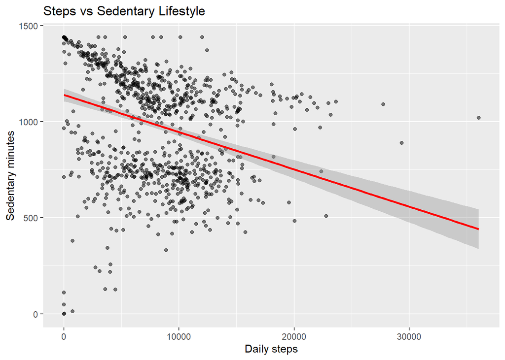

```r
ggplot(activity, aes(x = TotalSteps, y = SedentaryMinutes)) +
  geom_point(alpha = 0.5) +
  geom_smooth(method = "lm", color = "red") +
  labs(title = "Steps vs Sedentary Lifestyle", x = "Daily steps", y = "Sedentary minutes")
```

The results show a predictable trend: people who walk more tend to be less sedentary. Although this is not surprising, it provides useful feedback on the quality of the available data at our disposal, confirming that the data is consistent, reliable, and aligned with expectations.

### Pearson correlation coefficient

The Pearson correlation coefficient measures the strength and direction of the linear relationship between two variables. In my case the variables are TotalSteps, which indicates the total steps taken and SedentaryMinutes, which indicates the minutes of sedentary time. I also excluded the rows that contained missing NA values.

```r
cor(activity$TotalSteps, activity$SedentaryMinutes, use = "complete.obs")
```

```
## [1] -0.3274835
```

**Insight**: moderately negative correlation (r = -0.33) → those who walk more tend to be less sedentary. However, there are exceptions, such as intense walks followed by long periods of inactivity or intense physical activity not attributable to walking.

**Recommended data-driven strategy**: suggest short exercise sessions on days characterized by high sedentary activity through personalized notifications. Physical activity can be incentivized through a reward program, which rewards users for reaching minimum daily goals (gamification). This approach could help reduce average levels of sedentary activity.

## Insight 2: Sleep and physical activity

I want to find out if there is a correlation between the number of daily steps and the amount of sleep on the night **of the same day** for trained users, i.e. Fitbit. I want to investigate whether, in some cases, sleeping more than usual is related to a need for recovery after intense days or to a more sedentary lifestyle. To this end, it was necessary to standardize the date formats in the two datasets. In particular, in the activity dataset, the ActivityDate column was converted from a string to a date format. In the sleep dataset, however, the SleepDay column was transformed into dates starting from a date and time format. An inner_join command is used to match the two datasets by date and user.

```r
activity <- activity %>% mutate(ActivityDate = mdy(ActivityDate))
sleep <- sleep %>% mutate(SleepDay = as_date(mdy_hms(SleepDay)))
merged <- inner_join(activity, sleep, by = c("Id", "ActivityDate" = "SleepDay"))
```

The resulting graph shows the relationship between daily steps and recorded minutes of sleep:

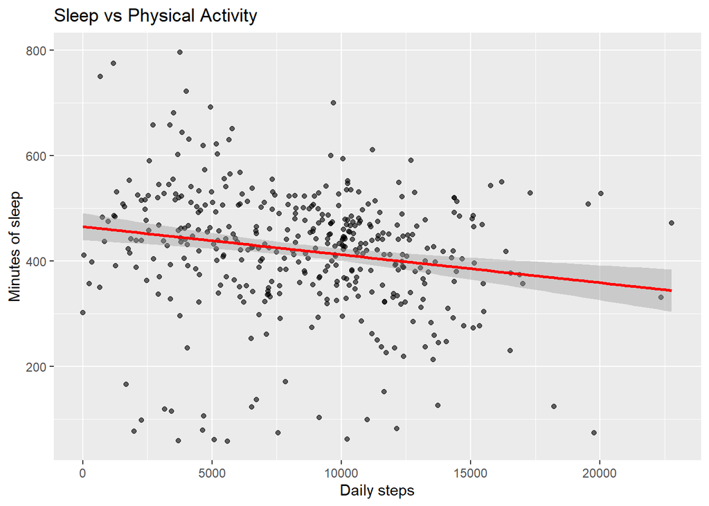

```r
ggplot(merged, aes(x = TotalSteps, y = TotalMinutesAsleep)) +
  geom_point(alpha = 0.6) +
  geom_smooth(method = "lm", color = "red") +
  labs(title = "Sleep vs Physical Activity", x = "Daily steps", y = "Minutes of sleep")
```

```r
cor( merged$TotalSteps, merged$TotalMinutesAsleep, use = "complete.obs")
```

```
## [1] -0.1868665
```

**Insight:** There is a slightly negative correlation (r = -0.19) and that is, those who move less tend to sleep more. This reflects the behavioral trend of users during periods of low physical activity, which are probably the “recovery” periods.

**Recommended data-driven strategy:** Classify days as “recovery” vs “active”. On “recovery” days, provide targeted advice such as: *“Did you sleep a lot? Today we suggest yoga or light stretching.”* This could help to carry out monitored and controlled physical activity, albeit less intense, during recovery periods.

## Insight 3: Average Sleep Duration

It is interesting to compare the average sleep hours of Fitbit users and those of non-Fitbit users, i.e. those from the Sleep health and lifestyle dataset who are not very active.

### Average Sleep Duration – Fitbit Users (in hours)

The histogram below represents the distribution of average sleep hours for Fitbit users. Each bar indicates the number of users who are associated with a certain average sleep duration, with intervals of 0.5 hours. The red dotted line indicates the overall average sleep hours and the exact value is reported next to the line itself.

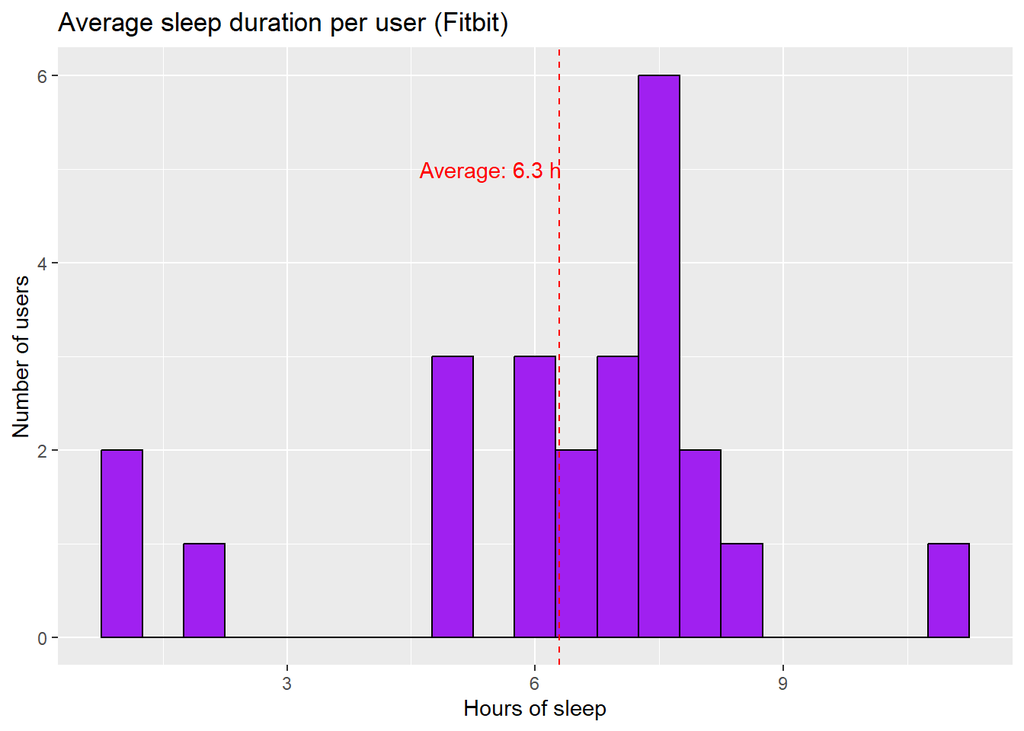

```r
# Calculating the average hours of sleep for each Fitbit user
sleep_avg <- sleep %>%
  group_by(Id) %>%
  summarise(AvgSleep = mean(TotalMinutesAsleep, na.rm = TRUE) / 60)
# Calculating the average sleep hours value among all Fitbit users
sleep_avg_fitbit <- mean(sleep_avg$AvgSleep)
# Result plot
ggplot(sleep_avg, aes(x = AvgSleep)) +
  geom_histogram(binwidth = 0.5, fill = "purple", color = "black") +
  labs(title = "Average sleep duration per user (Fitbit)",
       x = "Hours of sleep", y = "Number of users") +
  geom_vline(xintercept = sleep_avg_fitbit, linetype = "dashed", color = "red") +
  annotate("text", x = sleep_avg_fitbit -0.83, y = 5,
           label = paste0("Average: ", round(sleep_avg_fitbit, 1), " h"),
           color = "red")
```

### Average Sleep Duration – Non-Fitbit Users (in hours)

I apply the same method for non-Fitbit users:

[figure not shown]

```r
#  Removing N/A values
sleep_health_clean <- sleep_health %>%
  filter(!is.na(Sleep.Duration))
# Calculating Average Sleep Hours for Non-Fitbit Users
sleep_avg_non_fitbit <- mean(sleep_health_clean$Sleep.Duration)
# Result plot
ggplot(sleep_health_clean, aes(x = Sleep.Duration)) +
  geom_histogram(binwidth = 0.5, fill = "purple", color = "black") +
  labs(title = "Average sleep duration (non-Fitbit)",
       x = "Hours of sleep", y = "Number of users") +
  geom_vline(xintercept = sleep_avg_non_fitbit, linetype = "dashed", color = "red") +
  annotate("text", x = sleep_avg_non_fitbit + 0.3, y = 20,
           label = paste0("Average: ", round(sleep_avg_non_fitbit, 1), " h"),
           color = "red")
```

### Average Sleep Duration - Fitbit vs. Non-Fitbit Users Comparison

I can now compare the results to gain the insights I was looking for:

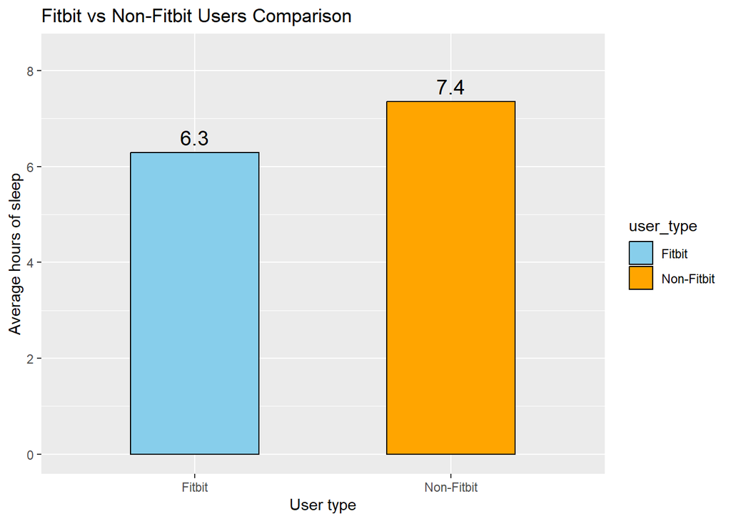

```r
# Summary dataframe for comparison:
sleep_comparison <- tibble(
  user_type = c("Fitbit", "Non-Fitbit"),
  avg_hr_sleep = c(sleep_avg_fitbit, sleep_avg_non_fitbit)
)
# Comparison Chart:
  ggplot(sleep_comparison, aes(x = user_type, y = avg_hr_sleep, fill = user_type)) +
  geom_col(width = 0.5, color = "black") +
  labs(title = "Fitbit vs Non-Fitbit Users Comparison",
       x = "User type", y = "Average hours of sleep") +
  scale_fill_manual(values = c("Fitbit" = "skyblue", "Non-Fitbit" = "orange")) +
  geom_text(aes(label = round(avg_hr_sleep, 1)), vjust = -0.5, size = 5) +
   ylim(0, max(sleep_comparison$avg_hr_sleep) + 1)
```

## Insight 4: Sleep Quality

### Sleep Quality - Fitbit Users

Since there is no variable in the Fitbit dataset that directly quantifies sleep quality, I decided to estimate it using the *Sleep Efficiency* parameter, defined as the ratio between *TotalMinutesAsleep* and *TotalTimeInBed*. This choice is based on the assumption that good sleep quality is achieved when most of the time spent in bed is actually dedicated to sleep. The following histogram shows the distribution of sleep efficiency for Fitbit users, i.e. the number of times the *SleepEfficiency* parameter is calculated equal to a given value between 0 and 1.

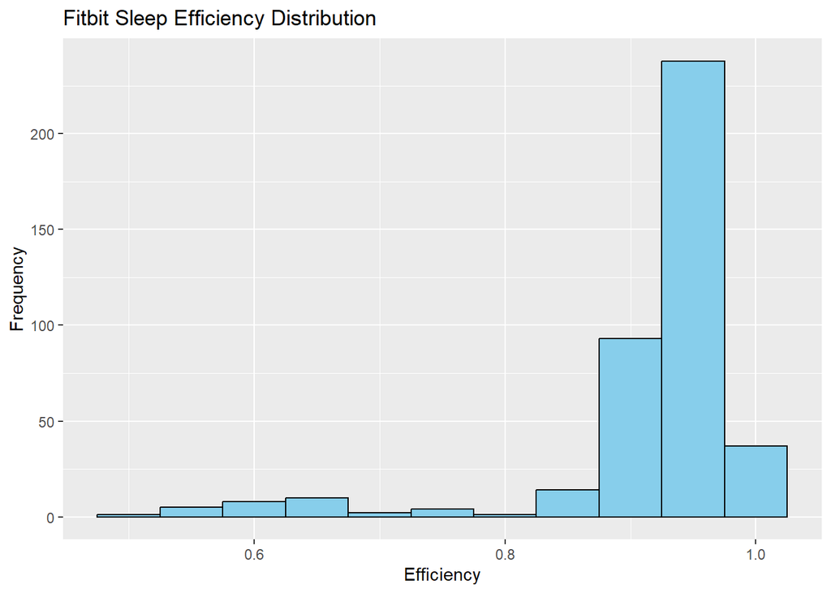

```r
sleep <- sleep %>% mutate(SleepEfficiency = TotalMinutesAsleep / TotalTimeInBed)

ggplot(sleep, aes(x = SleepEfficiency)) +
  geom_histogram(binwidth = 0.05, fill = "skyblue", color = "black") +
  labs(title = "Fitbit Sleep Efficiency Distribution", x = "Efficiency", y = "Frequency")
```

**Insight**: Fitbit users have a high average sleep efficiency (>85%), which suggests that the time spent in bed is generally used optimally for rest. However, a portion of the population shows a low sleep efficiency, with values below 70%, which may indicate possible cases of insomnia or other sleep disorders.

**Recommended data-driven strategy**: focus on promoting and raising awareness of a correct sleep cycle through personalized notifications for users with a medium-high level of physical activity.

### Sleep Quality - Non-Fitbit Users

For non-Fitbit users, sleep efficiency is a parameter already present in the variable *Quality.of.Sleep* of the respective dataset. The histogram shows that non-Fitbit users have a lower sleep efficiency on average (<85%) compared to the commonly recommended healthy range.

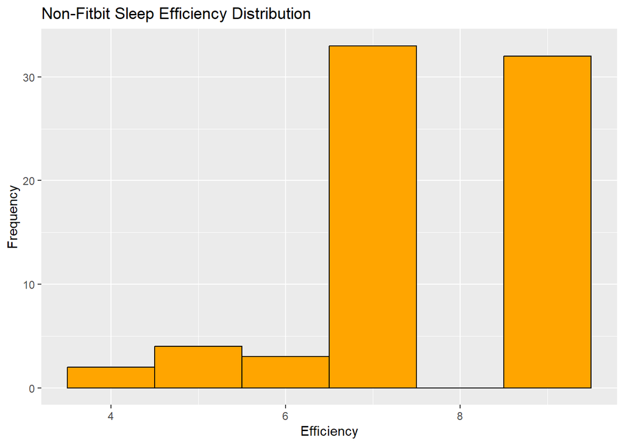

```r
ggplot(sleep_health_clean, aes(x = Quality.of.Sleep)) +
  geom_histogram(binwidth = 1, fill = "orange", color = "black") +
  labs(title = "Non-Fitbit Sleep Efficiency Distribution", x = "Efficiency", y = "Frequency")
```

### Sleep Quality Comparison

Comparing the results just found, the following comparative plot can be obtained:

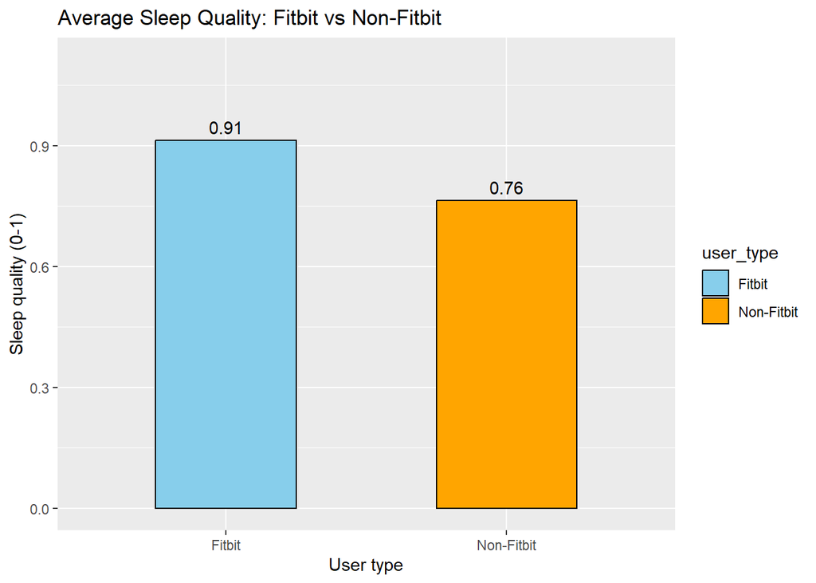

```r
# Sleep Efficiency Calculation for Each Fitbit User
sleep_efficiency_per_user <- sleep %>%
  group_by(Id) %>%
  summarise(avg_efficiency = mean(SleepEfficiency, na.rm = TRUE))

# Average sleep quality for Fitbit users (0–1)
quality_fitbit <- mean(sleep_efficiency_per_user$avg_efficiency, na.rm = TRUE)

# Average sleep quality for non-Fitbit users (normalized to a 0–1 scale)
quality_non_fitbit <- mean(sleep_health_clean$Quality.of.Sleep / 10, na.rm = TRUE)

# Comparison table
quality_comp <- tibble(
  user_type = c("Fitbit", "Non-Fitbit"),
  QualitySleep = c(quality_fitbit, quality_non_fitbit)
)

# Chart
ggplot(quality_comp, aes(x = user_type, y = QualitySleep, fill = user_type)) +
  geom_col(width = 0.5, color = "black") +
  labs(title = "Average Sleep Quality: Fitbit vs Non-Fitbit",
       x = "User type", y = "Sleep quality (0-1)") +
  scale_fill_manual(values = c("Fitbit" = "skyblue", "Non-Fitbit" = "orange")) +
  geom_text(aes(label = round(QualitySleep, 2)), vjust = -0.5) +
  ylim(0, max(quality_comp$QualitySleep) + 0.2)
```

## Insight 5: Heart Rate Comparison

Another level of analysis can be gleaned from the heart rate data. My question is: *do Fitbit users have a lower average heart rate, potentially reflecting a higher fitness level, or do they show higher values, perhaps due to more frequent monitoring during exercise?* This comparison opens up an interesting potential line of research into how the use of monitoring devices, combined with activity levels, influences biometric data.

```r
# Overall average heart rate for Fitbit users
heart_rate_avg_fitbit <- heartrate %>%
  group_by(Id) %>%
  summarise(AvgHeartRate = mean(Value, na.rm = TRUE)) %>%
  summarise(overall_avg = mean(AvgHeartRate)) %>%
  pull(overall_avg)
```

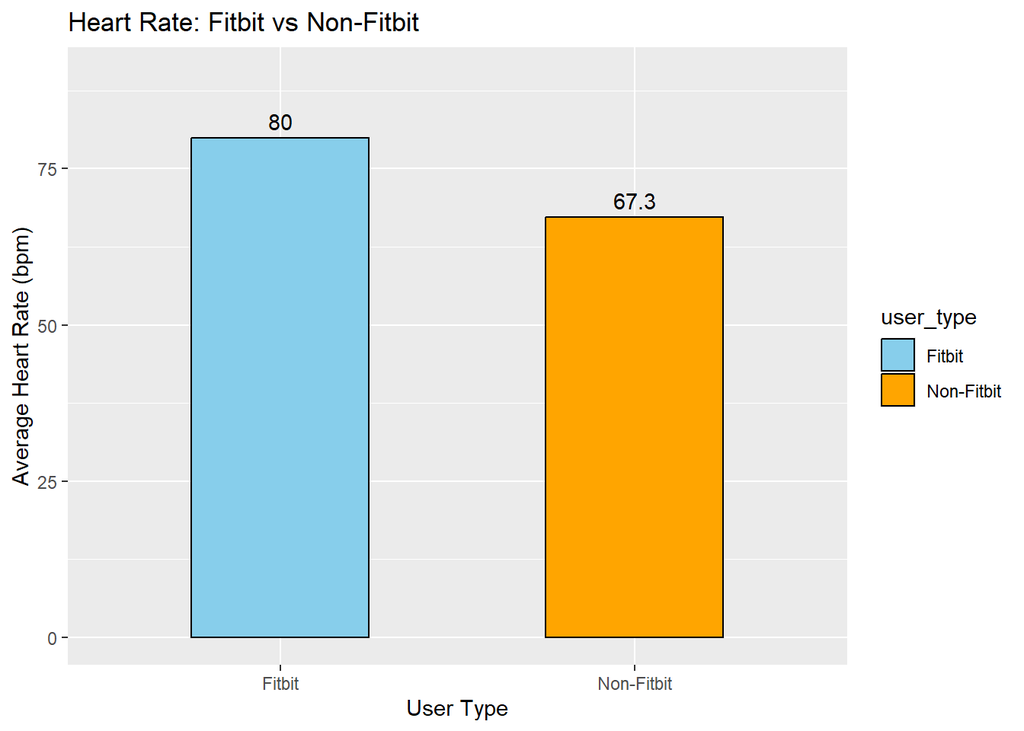

```r
# Calculating the average for non-Fitbit users
heart_rate_avg_nonfitbit <- mean(sleep_health$Heart.Rate, na.rm = TRUE)

# Comparison table
heart_rate_comp <- tibble(
  user_type = c("Fitbit", "Non-Fitbit"),
  heart_rate_c = c(heart_rate_avg_fitbit, heart_rate_avg_nonfitbit)
)

# Bar chart
ggplot(heart_rate_comp, aes(x = user_type, y = heart_rate_c, fill = user_type)) +
  geom_col(width = 0.5, color = "black") +
  labs(title = "Heart Rate: Fitbit vs Non-Fitbit",
       x = "User Type", y = "Average Heart Rate (bpm)") +
  scale_fill_manual(values = c("Fitbit" = "skyblue", "Non-Fitbit" = "orange")) +
  geom_text(aes(label = round(heart_rate_c, 1)), vjust = -0.5) +
  ylim(0, max(heart_rate_comp$heart_rate_c) + 10)
```

# Act

The $\underline{\href{https://bellabeat.com/product/leaf-chakra/}{Bellabeat Leaf}}$ device aligns perfectly with the type of analysis performed. In addition to monitoring physical activity, sleep, menstrual cycle and stress levels, the Leaf is designed as a daily support for psychophysical well-being, rather than as a simple fitness tracker. The results of the analysis suggest new lines of development to make it even more competitive and engaging, especially for those seeking balance rather than performance.

1. It is aimed at a well-defined target that is consistent with the data: Bellabeat Leaf is one of the few devices designed specifically for a female audience that is attentive not only to physical activity, but also to physical and mental well-being. This aligns perfectly with the insights that emerged from my analysis: users with moderate or low physical activity but with a strong need for balance and well-being represent a segment with *high potential*. Other devices on the market are more performance- or technology-oriented, while the Leaf can be considered as a wellness tool, rather than a performance tool.
2. Mental health-focused approach: Unlike other fitness trackers, Bellabeat integrates functions related to meditation, menstrual cycle, stress and mindfulness from the beginning. Targeting that portion of users whose needs consist of the desire to reduce stress, sleep better, feel balanced, fits perfectly with the needs highlighted by the data.
3. Discreet and elegant design: The Bellabeat Leaf stands out for its aesthetics, which recall that of a jewel, and which makes it perfectly integrable into everyday clothing, without the “tech” aspect of other fitness trackers. This feature favors constant and daily use even in work or formal contexts, improving the frequency and quality of monitoring. Greater continuity in the data collected allows for more reliable analysis, more effective personalized suggestions and greater adherence to wellness goals.

[figure not shown]

Bellabeat Leaf Urban and Bellabeat Leaf Chakra

In light of this, I suggest targeting the advertising campaign to: - users of other fitness trackers, highlighting the added value of integrating a personalized sleep plan into physical activity, clearly distinguishing themselves from competitors - active but not necessarily sporty women, seeking a balance between work, family and health, who would find the Leaf to be the right compromise between aesthetics and functionality - people subject to stress or sleep disorders, who would benefit from careful monitoring and personalized suggestions for their sleep plan

Topics to leverage: - reduction of daily stress - prevention and awareness of one’s body - holistic well-being, understood as a balance between mind, body and emotions, without “performance” pressure

Additional features that I recommend implementing: - smart alerts to suggest regenerative breaks (stretching, breathing exercises, yoga) when signs of stress or prolonged inactivity are detected - smart recommendations based on recorded data, such as the ideal time to go to sleep based on the physical state and stress detected in the previous days - gamification (goals, rewards, challenges) and community, to strengthen daily engagement - partnerships with meditation apps or digital nutritionists, creating a 360° integrated wellness ecosystem - data collection directly from Bellabeat users to enhance future analyses - distinction between light/deep sleep, to improve recommendations on sleep cycles - integration of psychological indicators of the state of stress encountered

## Conclusion

The Bellabeat Leaf is already a unique device in the wearable tech landscape, but with some targeted interventions it can become a **point of reference** for female wellness. In a market saturated with devices that simply *track*, Bellabeat has the concrete opportunity to emerge as the **only** to offer a complete, personalized and truly useful wellness experience in everyday life.